# Albacore Logbook Distribution Models

### Spatial and spatiotemporal fields

This model has a baseline spatial field, representing the May/June spatial intercept. Then, there are spatiotemporal fields (`epsilon_st`) for each year, and a field for July/Aug/Sep and October/November.

First, the May/June spatial field:

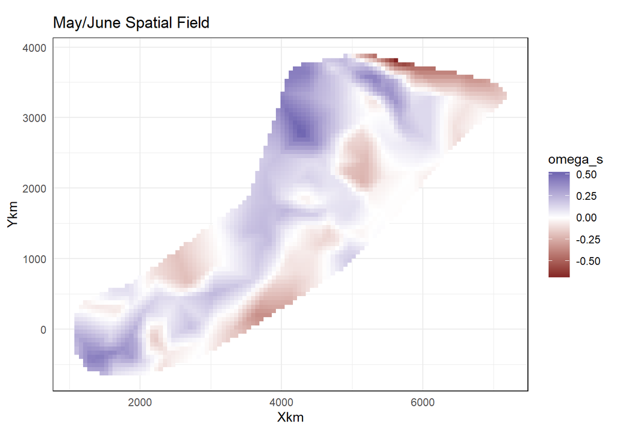

```r
quickmap(pred3,omega_s)+
  labs(title="May/June Spatial Field")
```

July/Aug/Sep:

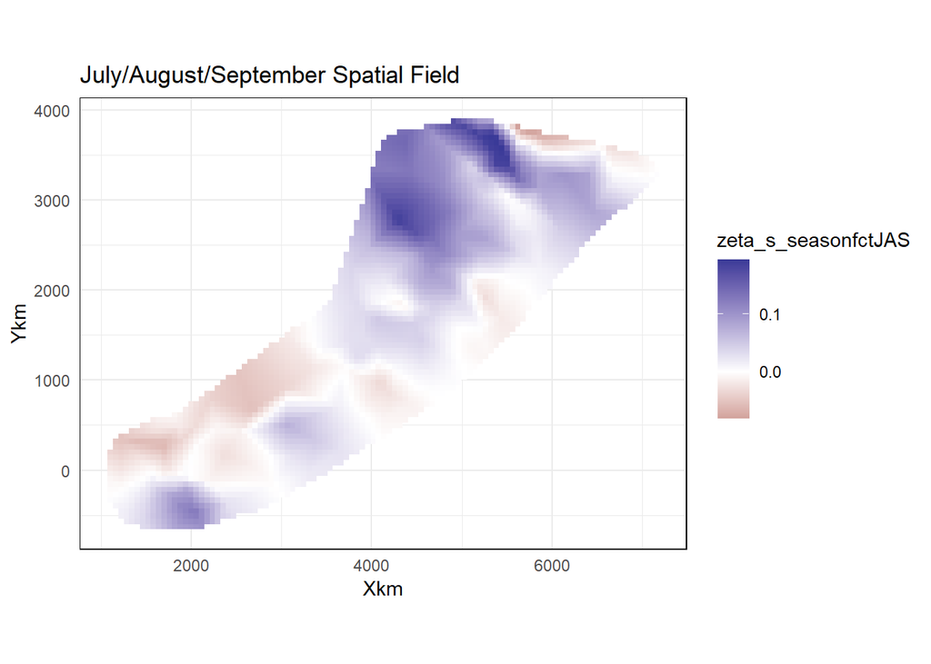

```r
quickmap(pred3,zeta_s_seasonfctJAS)+
  labs(title="July/August/September Spatial Field")
```

October/November

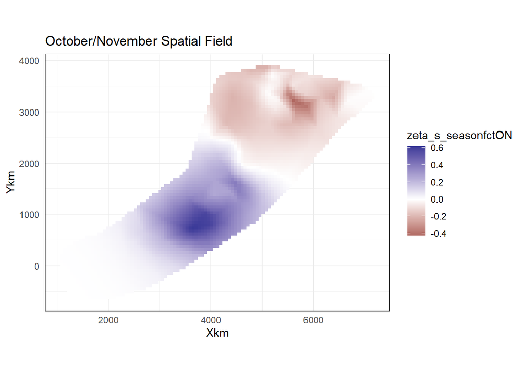

```r
quickmap(pred3,zeta_s_seasonfctON)+
  labs(title="October/November Spatial Field")
```

And now, the spatiotemporal fields, by year

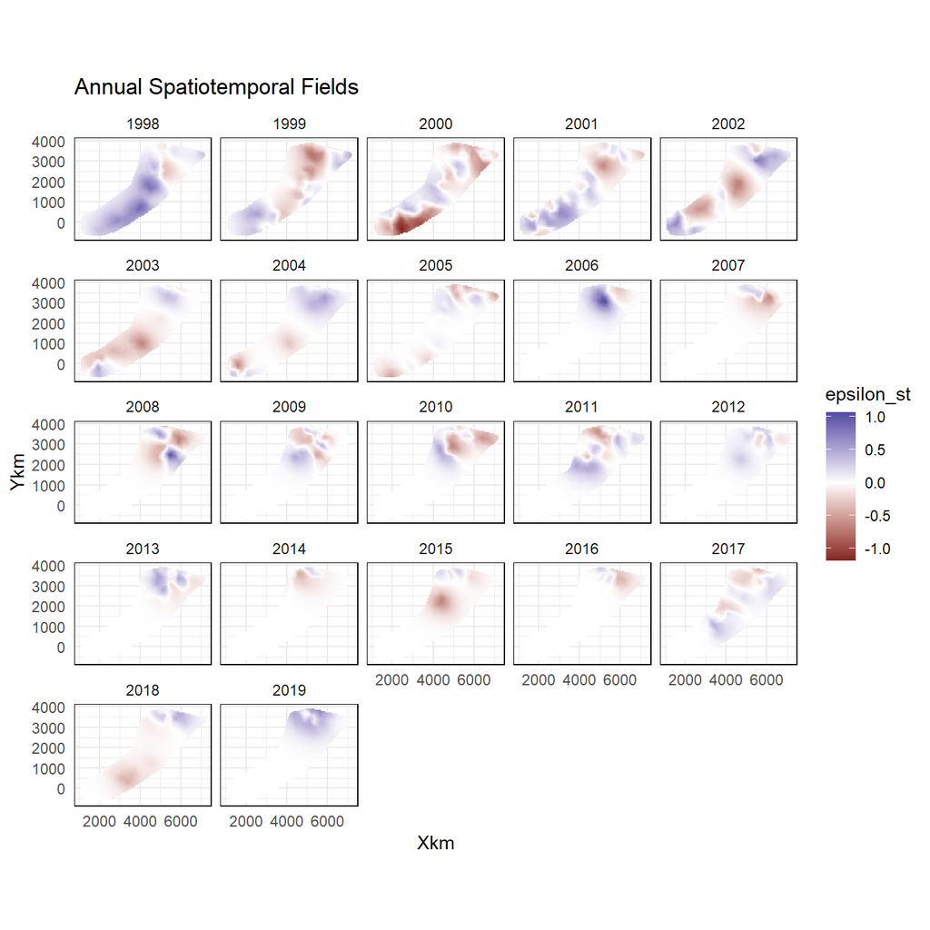

```r
quickmap(pred3,epsilon_st)+
  facet_wrap(~year)+
  labs(title="Annual Spatiotemporal Fields")
```

And the same, but adding the scalar year effect

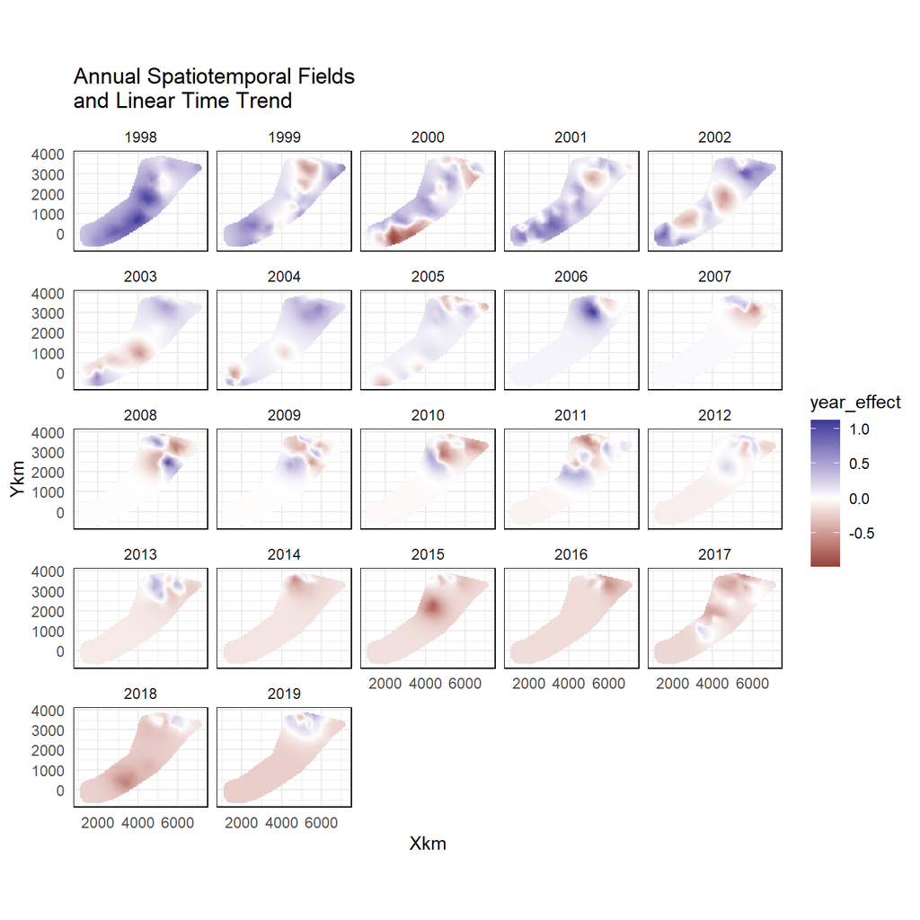

```r
coefs <- tidy(m3,conf.int = T)
scaled_year_coef <- coefs$estimate[coefs$term == "scaled_year"]
pred3 |>
  mutate(year_effect=scaled_year_coef*scaled_year+epsilon_st) |>
  quickmap(year_effect)+facet_wrap(~year)+
  labs(title="Annual Spatiotemporal Fields\nand Linear Time Trend")
```

### CPUE predictions

Predictions

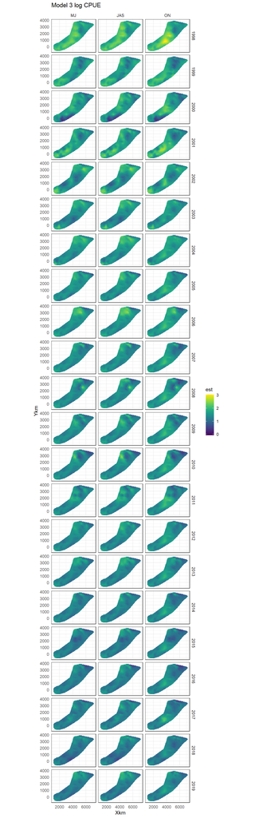

```r
quickmap(pred3,est)+facet_grid(year~seasonfct)+
  scale_fill_viridis(option="D")+
  labs(title="Model 3 log CPUE")
```

And uncertainty

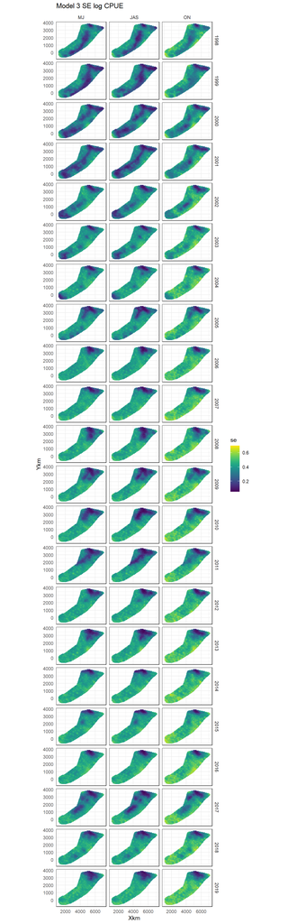

```r
psim <- predict(m3, newdata = gr_ssn_yrs, nsim = 200, sims_var = "est")
pred3$se <- apply(psim, 1, sd)
quickmap(pred3,se)+
  facet_grid(year~seasonfct)+
  scale_fill_viridis(option="D")+
  labs(title="Model 3 SE log CPUE")
```

### Predicted/observed

As with the other models, we can compare predicted to observed and look for any issues with residuals.

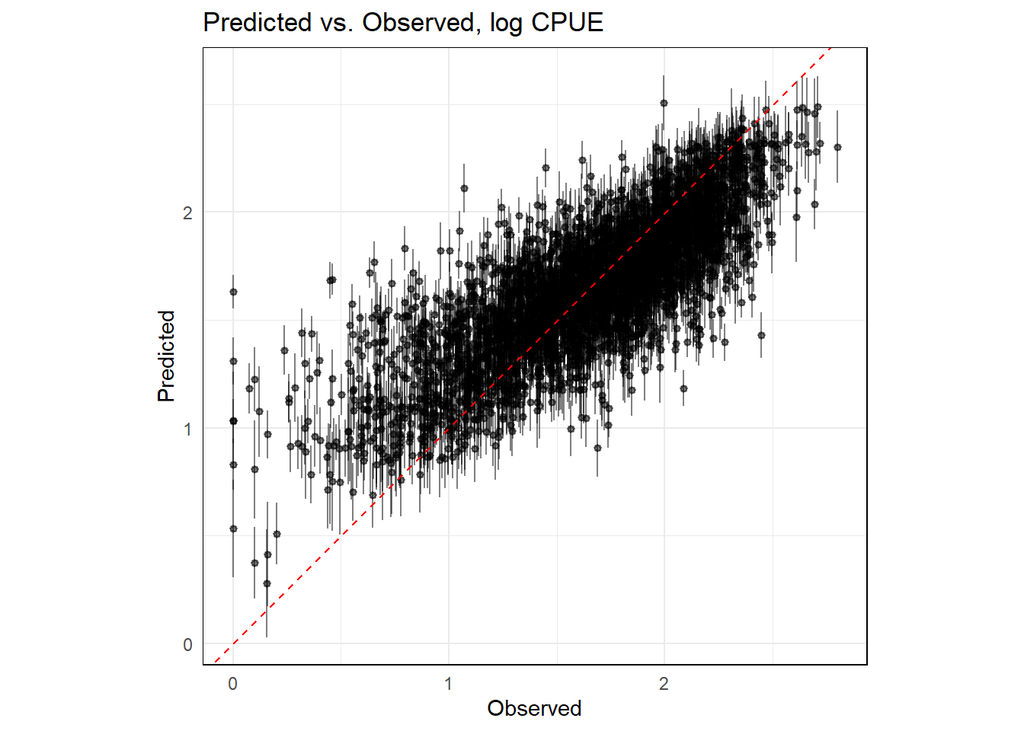

```r
predobs <- predict(m3)
psim <- predict(m3,nsim=200)
predobs$se_est <- apply(psim,1,sd)

predobs |>
  ggplot(aes(mean_logCPUE,est,ymax=est+se_est,ymin=est-se_est))+
  geom_pointrange(size=0.25,alpha=0.5)+
  coord_equal()+
  labs(x="Observed",y="Predicted",title="Predicted vs. Observed, log CPUE")+
  geom_abline(slope=1,intercept=0,color="red",linetype=2)
```

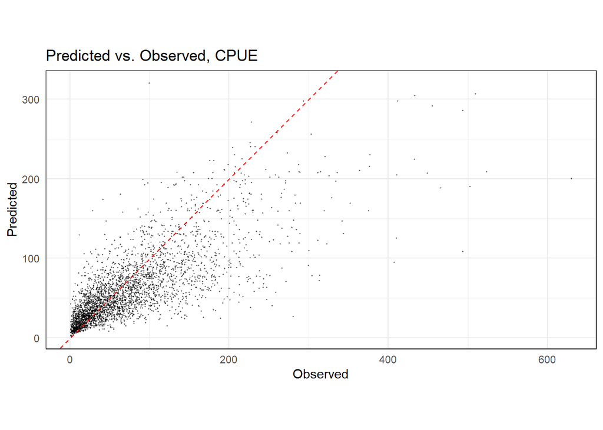

```r
predobs |>
  ggplot(aes(10^mean_logCPUE,10^est))+
  geom_point(size=0.25,alpha=0.5)+
  coord_equal()+
  labs(x="Observed",y="Predicted",title="Predicted vs. Observed, CPUE")+
  geom_abline(slope=1,intercept=0,color="red",linetype=2)
```

These are smoothed histograms of the distribution of CPUE in the data (“observed”) vs. the fitted model (“estimated”). We can see that the model is still a little bit “mean-centered” (i.e., the estimated values have a smaller variance), with not as many extreme values on the high or low end.

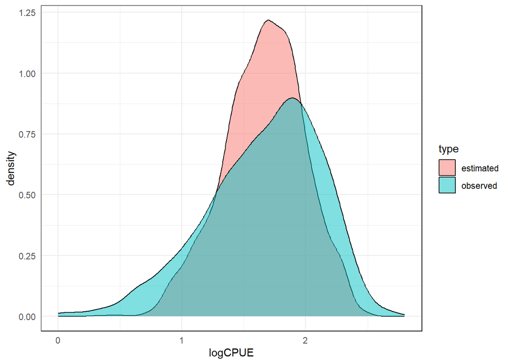

```r
predobs |>
  dplyr::select(observed=mean_logCPUE,estimated=est) |>
  pivot_longer(everything(),names_to="type",values_to="logCPUE") |>
  ggplot(aes(logCPUE,fill=type))+geom_density(alpha=0.5)
```

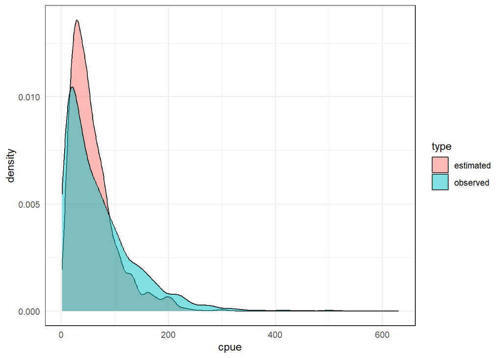

```r
predobs |>
  dplyr::select(observed=mean_logCPUE,estimated=est) |>
  pivot_longer(everything(),names_to="type",values_to="logCPUE") |>
  mutate(cpue=10^logCPUE) |>
  ggplot(aes(cpue,fill=type))+geom_density(alpha=0.5)
```

### COG

We can also use our model to estimate the center of gravity in each year, representing the centroid of fishing activity.

```r
# predcog <- predict(m3,newdata=gr_ssn_yrs,nsim=200)
# m3cogY <- get_range_edge(predcog,axis=gr_ssn_yrs$Ykm,quantiles=c(0.025,0.50,0.975))
# m3cogX <- get_range_edge(predcog,axis=gr_ssn_yrs$Xkm,quantiles=c(0.025,0.50,0.975))
# m3cog <- m3cogY |>
#   mutate(axis="Y") |>
#   bind_rows(mutate(m3cogX,axis="X"))
# m3cog |>
#   ggplot(aes(year,est,ymax=upr,ymin=lwr,fill=factor(quantile)))+
#   geom_ribbon()+
#   geom_line()+
#   facet_wrap(~axis,scales='free')
```

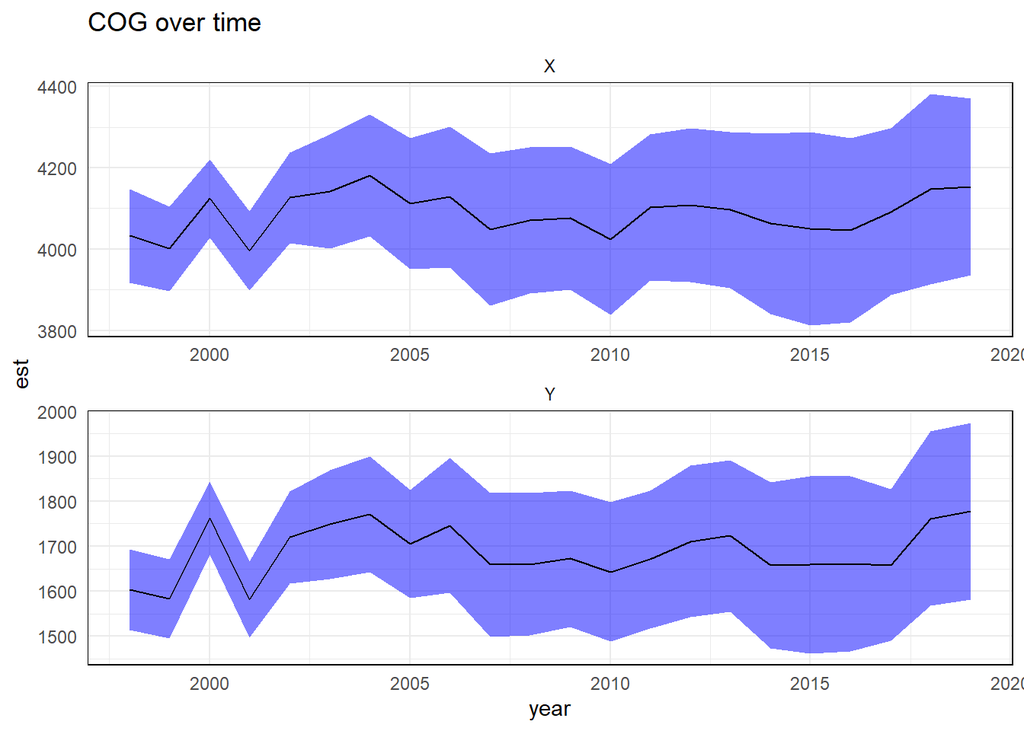

```r
predcog2 <- predict(m3,newdata=gr_ssn_yrs,return_tmb_object=T)
m3cog <- get_cog(predcog2,format="wide")
m3cog2 <- get_cog(predcog2)

# in 1D
m3cog2 |>
  ggplot(aes(year,est,ymax=upr,ymin=lwr))+
  geom_ribbon(fill="blue",alpha=0.5)+
  geom_line()+
  labs(title="COG over time")+
  facet_wrap(~coord,scales='free',nrow=2)
```

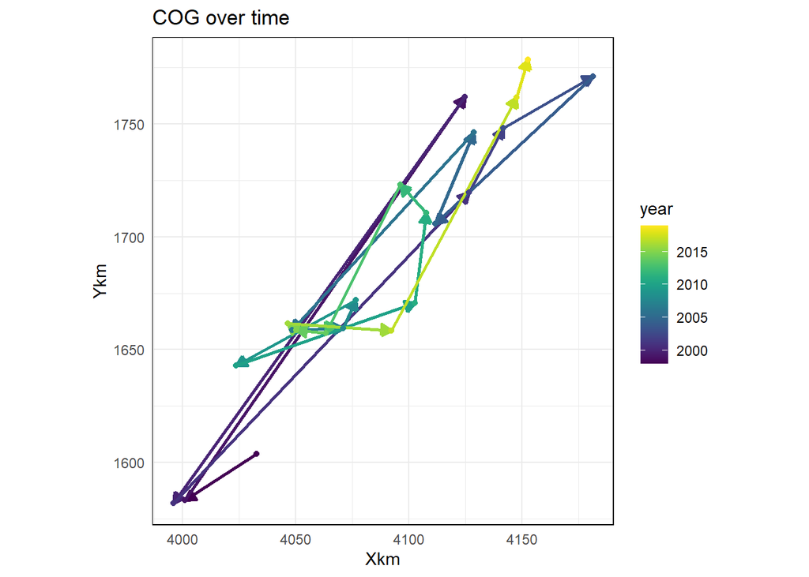

```r
# in 2D
m3cog |>
  mutate(xend=lead(est_x),yend=lead(est_y)) |>
  ggplot(aes(est_x,est_y,xend=xend,yend=yend,color=year))+
  geom_segment(linewidth=1,arrow=arrow(type = 'closed',length=unit(0.25,'cm')))+
  geom_point()+
  coord_fixed()+
  scale_color_viridis()+
  labs(title="COG over time",x="Xkm",y="Ykm")
```

Over time, it appears that the center of fishing activity has varied over time, but in more recent years has shifted in a northeast direction.